# 비지도학습이란?

##### 지도학습과는 달리 정답(Y)이 없는 데이터를 가지고 학습하는 것이다

##### 비지도학습의 목표는 해당 데이터의 패턴, 특성 및 구조를 스스로 파악하여 이를 통해 데이터가 어떻게 구성되었는지 새로운 규칙성을 알아내는 과정

##### 비지도학습은 크게 군집분석과 차원축소로 나눌 수 있다

### Clustering - 군집분석

##### 군집분석은 비지도학습(unsupervised learning)의 일종으로 유사한 데이터끼리 그룹화를 시키는 학습모델을 말한다. 각 데이터의 유사성을 측정하여, 유사성이 높은 집단끼리 분류하고 군집간에 상이성을 규명하는 방법이다

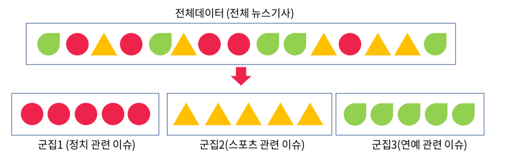

```python
from IPython.display import Image
image_path = 'C:/Users/jaemi/OneDrive/Desktop/비지도학습/kmeans/img1.png'
Image(filename=image_path, width=800)
```

##### 위의 그림을 보면 raw data에는 여러가지 종류가 섞여있다. 섞여있는 raw data를 군집분석을 통해 서로 다른 특성을 가진 군집으로 분류한다. 이때, 분류문제와는 다르게 target Y가 존재하지 않는다. 그렇기에 학습과정에 있어서 정답을 맞출 기준표가 없는 것이다.

##### 위의 그림은 기사에 대한 군집분석을 보여준다. 각 군집은 이슈별로 정리된 결과를 도출했다. 이처럼 군집분석은 raw data에서 segmentation을 통해 insight를 도출하고, 이를 특정 활용하여 마케팅/특정 프로모션등으로 활용할 수 있다. 물론 군집 별 추가 분석을 수행하여 새로운 더 심화적인 insight를 도출할 수도 있다.

##### 이러한Clustering의 종류로는 대표적으로

##### -K-means clustering : 데이터를 사용자가 지정한 k개의 군집으로 나눈다.

##### -계층적 군집분석(Hierarchical clustering) : 나무 모양의 계층적 구조를 형성하여 군집분석을 수행한다.

##### -DBSCAN : k개를 설정할 필요없이 인근에 있는 데이터를 따라가며 군집화 할 수 있다.

##### 와 같은 종류들이 있다

### K-means clustering

##### K-means clustering은 각 군집에 할당된 포인트들의 평균 좌표를 이용해서 중심점을 반복적으로 업데이트하며 군집을 형성하는 알고리즘이다. 학습과정은 다음과 같다.

##### 1. 각 데이터 포인트에 대해서 가장 가까운 중심점을 찾고, 그 중심점에 해당하는 군집을 할당한다.

##### 2. 할당된 군집을 기반으로 새로운 중심을 계산한다. 중심점은 군집 내부 점들의 좌표 평균으로 한다.

##### 3. 각 클러스터의 할당된 중심점이 바뀌지 않을 때까지 반복한다.

##### 아래 그림을 봐보자

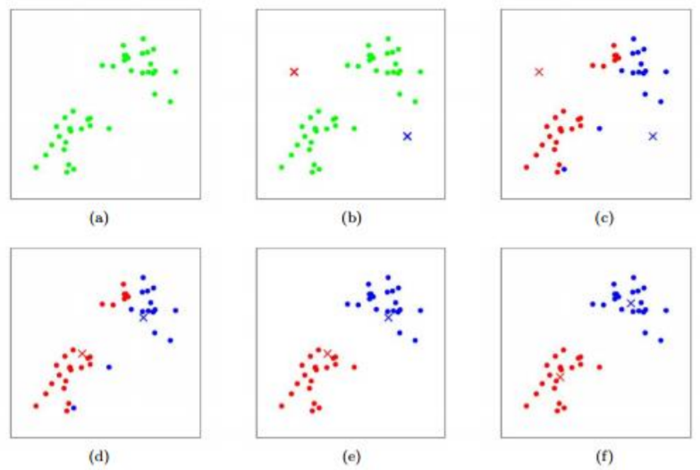

```python
image_path = 'C:/Users/jaemi/OneDrive/Desktop/비지도학습/kmeans/img2.png'
Image(filename=image_path, width=700)
```

##### 먼저 raw data상태인 (a)에서는 아무런 포인트와 군집이 형성되지 않는다. (b)에서처럼 포인트를 할당한다.

##### 이때 포인트의 개수는 사용자가 직접 K를 지정해주어야 한다. 위의 그림에서는 K=2이다. 이 포인트를 기반으로 (c)에서처럼 가까운 점들을 분류한다.

##### (d)에서 분류된 점들의 중심점을 찾기위해 평균을 사용하여 군집의 중심점 방향으로 포인트를 업데이트 시킨다.

##### (e)에서는 업데이트된 포인트에 맞게 다시 군집을 재형성한다. (f) 다시 포인트를 찾으며 더이상 이 할당된 점이 바뀌지 않으면 학습을 종료한다.

##### 이때, 포인트와 해당 군집에 대해서 거리를 기반으로 평균을 내고 학습을 진행한다.

##### 이때 사용되는 거리는 대표적으로 맨하탄거리(Manhattan distance)와 유클리디안거리(Euclidean distance)가 존재한다.

##### 맨하탄거리는 쉽게말해서 지도에서 사용하는 거리방식이고, 유클리디안 거리는 점과 점 사이의 가장 짧은 거리를 계산하는 방식이다.

##### 수식은 아래와 같다.

[figure not shown]

```python
image_path = 'C:/Users/jaemi/OneDrive/사진/스크린샷/수식2.png'
Image(filename=image_path, width=400)
```

### 최적 군집의 수(K) 결정

##### 군집을 형성할 개수(중심점 개수) K는 사용자가 직접 지정해야하는 parameter라고 하였다.

##### 최적의 K를 어떻게 정해야할까? 이 K를 설정하는 대표적인 방법은 Elbow method와 Silhouette method가 있다.

#### -Elbow method

##### Elbow method는 군집간 분산(BSS; Between cluster Sum of Squares)과 전체분산(TSS = BSS + WSS)의 비율을 고려하는 것이다

```python
image_path = 'C:/Users/jaemi/OneDrive/사진/스크린샷/수식3.png'
Image(filename=image_path, width=200)
```

[output not shown]

```python
image_path = 'C:/Users/jaemi/OneDrive/사진/스크린샷/수식4.png'
Image(filename=image_path, width=200)
```

[output not shown]

##### 이를 활용하여, 군집간 분산과 전체 분산의 비율은 아래와 같이 표현할 수 있다.

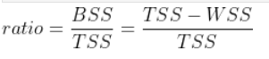

```python
image_path = 'C:/Users/jaemi/OneDrive/사진/스크린샷/수식5.png'
Image(filename=image_path, width=250)
```

##### 이때, 비율의 한계비용(marginal cost)이 완곡하게 줄어드는 지점이 최적의 클러스터 개수이다.

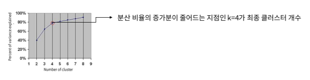

```python
image_path = 'C:/Users/jaemi/OneDrive/Desktop/비지도학습/kmeans/img8.png'
Image(filename=image_path, width=1000)
```

##### 또한, WWS를 통해 비율의 한계비용(marginal cost)이 줄어드는 지점이 최적의 클러스터 개수로 볼 수도 있다.

```python
image_path = 'C:/Users/jaemi/OneDrive/사진/스크린샷/수식7.png'
Image(filename=image_path, width=200)
```

[output not shown]

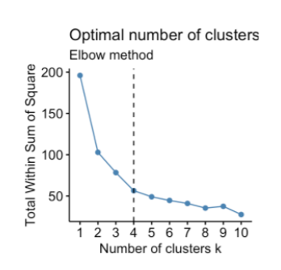

```python
image_path = 'C:/Users/jaemi/OneDrive/Desktop/비지도학습/kmeans/img10.png'
Image(filename=image_path, width=400)
```

##### 위의 그림을 보면 k=4에서 급격하게 줄어드므로 군집의 개수(k)를 4개로 한다.

#### -Silhouette method

##### Silhouette method는 객체와 그 객체가 속한 군집의 데이터들과의 비유사성(dissimilarity)을 계산하는 방법이다.

##### 그리고 Silhouette method는 elbow method에 비해 상대적으로 간단하다.

##### a(i)는 객체i와 그 객체가 속한 군집의 데이터들과의 비유사성을 뜻한다. 여기서 g(x_i)는 x_i가 속한 군집을 말한다.

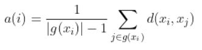

```python
image_path = 'C:/Users/jaemi/OneDrive/사진/스크린샷/수식10.png'
Image(filename=image_path, width=250)
```

##### b(i)는 그 객체가 속하지 않은 다른 군집의 모든 데이터들과의 비유사성의 최소값을 말한다(즉, 가장 가까운 군집을 말한다).

##### 여기서 g_k는 x_i가 속하지 않은 다른 군집 k를 말한다.

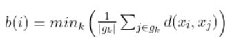

```python
image_path = 'C:/Users/jaemi/OneDrive/사진/스크린샷/수식11.png'
Image(filename=image_path, width=280)
```

##### 이렇게 a(i)와 b(i)가 정의되었다면, 실루엣 s(i)는 아래와 같이 계산된다.

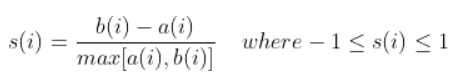

```python
image_path = 'C:/Users/jaemi/OneDrive/사진/스크린샷/수식12.png'
Image(filename=image_path, width=380)
```

##### 여기서 s(i)의 값이 1에 가까울수록 객체 i는 올바른 클러스터에 분류된 것이다.

##### 그리고 k를 증가시키면서 평균 실루엣 값(silhouette coefficient)이 최대가 되는 k를 선택한다.

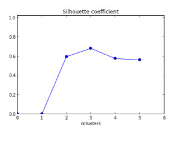

```python
image_path = 'C:/Users/jaemi/OneDrive/Desktop/비지도학습/kmeans/img14.png'
Image(filename=image_path, width=500)
```

##### 이 위의 예시를 본다면 1에 가장 가까운 k=3를 선택해야 하는 것이다.

### K-means clustering 파이썬 실습

#### 1. 데이터 준비

##### sklearn에서 제공해주는 iris 데이터를 사용한다.

##### clustering이기에 종속변수를 제외하고 독립변수만으로 데이터프레임을 구성한다.

```python
#실습 데이터 Load & Dataframe 변환
from sklearn import datasets
import pandas as pd

iris = datasets.load_iris()
y = pd.DataFrame(iris.target)
y.columns=['labels']
data = pd.DataFrame(iris.data)
data.columns=['Sepal length','Sepal width','Petal length','Petal width']
data = pd.concat([data,y],axis=1)

data.head()
```

|  | Sepal length | Sepal width | Petal length | Petal width | labels |
| --- | --- | --- | --- | --- | --- |
| 0 | 5.1 | 3.5 | 1.4 | 0.2 | 0 |
| 1 | 4.9 | 3.0 | 1.4 | 0.2 | 0 |
| 2 | 4.7 | 3.2 | 1.3 | 0.2 | 0 |
| 3 | 4.6 | 3.1 | 1.5 | 0.2 | 0 |
| 4 | 5.0 | 3.6 | 1.4 | 0.2 | 0 |

```python
df = data[ ['Sepal length','Sepal width','Petal length','Petal width']]
df.head()
```

|  | Sepal length | Sepal width | Petal length | Petal width |
| --- | --- | --- | --- | --- |
| 0 | 5.1 | 3.5 | 1.4 | 0.2 |
| 1 | 4.9 | 3.0 | 1.4 | 0.2 |
| 2 | 4.7 | 3.2 | 1.3 | 0.2 |
| 3 | 4.6 | 3.1 | 1.5 | 0.2 |
| 4 | 5.0 | 3.6 | 1.4 | 0.2 |

#### 2. 최적 군집의 수(K) 결정

#### 2.1 Elbow method

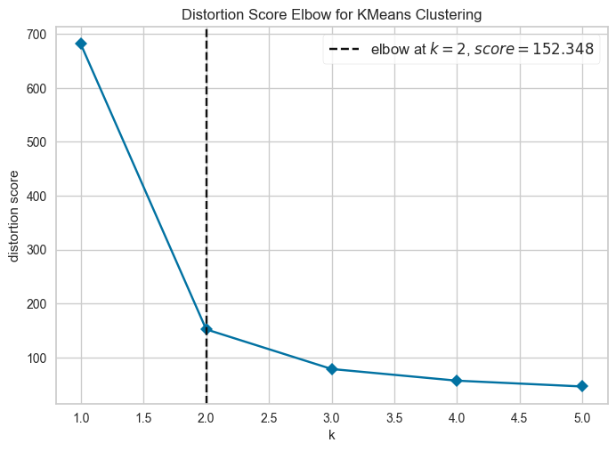

```python
from yellowbrick.cluster import KElbowVisualizer

k=0
model = KMeans(n_clusters=k, random_state=7)
visualizer = KElbowVisualizer(model, k=(1,6), timings=False)
visualizer.fit(df)
visualizer.show()
```

##### 위 그림에서 군집수 2개가 가장 최상의 군집 개수라고 추천하고 있다.

#### 2.2 Silhouette method

```python
from sklearn.metrics import silhouette_score, silhouette_samples

silhouette_avg = silhouette_score(df, model.labels_)
print(silhouette_avg)
```

[output not shown]

```python
for k in range(2, 6):
    model = KMeans(n_clusters=k, random_state=7).fit(df)
    silhouette_avg = silhouette_score(df, model.labels_)
    print(f'cluster : {k} // silhouette index {silhouette_avg}')
```

```
cluster : 2 // silhouette index 0.6810461692117465
cluster : 3 // silhouette index 0.5528190123564102
cluster : 4 // silhouette index 0.49805050499728815
cluster : 5 // silhouette index 0.48874888709310654
```

##### 위의 결과에서는 cluster 2개에서 가장 높은 index 값을 가졌으므로 2가 가장 유의한 cluster 개수라고 할 수 있다.

#### 3. 최적의 K로 K-means 모델 학습

##### sklearn의 모든 모델들과 같이 .fit명령어로 학습한다.

##### clustering은 비지도 학습이므로 독립변수만을 입력으로 받는다.

##### 다양한 parameter가 있지만 몇 개의 그룹으로 군집화할지를 고르는 n_cluster(k 지정) 인자와

##### K-평균 군집화는 초기 그룹 설정마다 최종 결과가 달라질 수 있어, 실행 시 마다 결과를 같게 만드는 random_state 인자만을 설정하고 학습시켜보겠다.

```python
from sklearn.cluster import KMeans
model = KMeans(n_clusters = 2, random_state=7)
model.fit(df)

new_labels =pd.DataFrame(model.labels_)
new_labels.columns=['cluster']

r = pd.concat([df,new_labels],axis=1)
```

#### 4. 결과 시각화

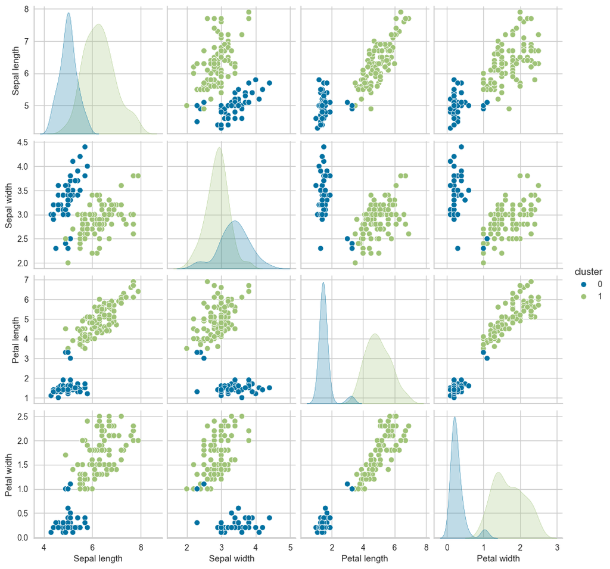

```python
#pairplot with Seaborn
sns.pairplot(r,hue='cluster')
plt.show()
```